# F9_10_LIAB_TOT_BOY

Total liabilities - beginning of year · Amount report

## Overview

**Description**

Beginnning of year

**Table**

`F9-P10-T00-BALANCE-SHEET` (one)

**Location code**

`F990-PC-PART-10-LINE-26-BOY`, `F990-EZ-PART-02-LINE-26-BOY`

**Family**

`F990-PC-PART-10-LINE-26-BOY`

**Data type**

numeric (xsd: USAmountNNType, USAmountType)

**Scope**

PZ

**Status**

unreviewed

7

xpaths mapped (4 observed)

5,083,401

filings with a value

2009–2024

tax years observed

3

open flags (0 errors)

## Flags

| Severity | Flag | Xpath | Detail |
| --- | --- | --- | --- |
| ⓘ info | `UNOBSERVED` | IRS990/Form990PartX/TotalLiabilities/BOY | never observed in TY2009-2024 filings |
| ⓘ info | `UNOBSERVED` | IRS990EZ/TotalLiabilities/BOY | never observed in TY2009-2024 filings |
| ⓘ info | `UNOBSERVED` | IRS990EZ/TotalLiabilitiesGrp/BOYAmt | never observed in TY2009-2024 filings |

## Xpaths

All mapped xpaths (under /Return/ReturnData or /Return/ReturnHeader), oldest first. Charts label each series by its xpath.

| Xpath | Form | First year | Last year | Versions | Filings | Repeats in |
| --- | --- | --- | --- | --- | --- | --- |
| IRS990/TotalLiabilities/BOY | 990 | 2009 | 2012 | 19 | 495,528 | 0.0% |
| IRS990EZ/SumOfTotalLiabilities/BOY | 990-EZ | 2009 | 2012 | 18 | 149,551 | 0.0% |
| IRS990/TotalLiabilitiesGrp/BOYAmt | 990 | 2013 | 2024 | 38 | 3,349,613 | 0.0% |
| IRS990EZ/SumOfTotalLiabilitiesGrp/BOYAmt | 990-EZ | 2013 | 2024 | 37 | 1,088,709 | 0.0% |
| IRS990/Form990PartX/TotalLiabilities/BOY | 990 |  |  |  | 0 |  |
| IRS990EZ/TotalLiabilities/BOY | 990-EZ |  |  |  | 0 |  |
| IRS990EZ/TotalLiabilitiesGrp/BOYAmt | 990-EZ |  |  |  | 0 |  |

## Coverage

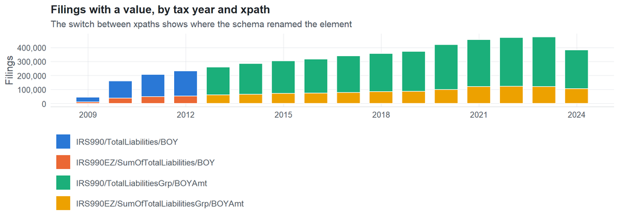

**Table view**

Table view: filings by tax year and series

| Tax year | IRS990/TotalLiabilities/BOY | IRS990EZ/SumOfTotalLiabilities/BOY | IRS990/TotalLiabilitiesGrp/BOYAmt | IRS990EZ/SumOfTotalLiabilitiesGrp/BOYAmt |
| --- | --- | --- | --- | --- |
| 2009 | 33,311 | 10,364 | 0 | 0 |
| 2010 | 123,025 | 37,609 | 0 | 0 |
| 2011 | 159,504 | 48,044 | 0 | 0 |
| 2012 | 179,688 | 53,534 | 0 | 0 |
| 2013 | 0 | 0 | 198,855 | 60,395 |
| 2014 | 0 | 0 | 218,619 | 66,344 |
| 2015 | 0 | 0 | 233,519 | 70,824 |
| 2016 | 0 | 0 | 243,903 | 73,730 |
| 2017 | 0 | 0 | 261,612 | 78,483 |
| 2018 | 0 | 0 | 271,442 | 84,562 |
| 2019 | 0 | 0 | 283,694 | 87,435 |
| 2020 | 0 | 0 | 320,343 | 99,041 |
| 2021 | 0 | 0 | 336,488 | 120,692 |
| 2022 | 0 | 0 | 349,062 | 121,641 |
| 2023 | 0 | 0 | 354,774 | 120,395 |
| 2024 | 0 | 0 | 277,302 | 105,167 |

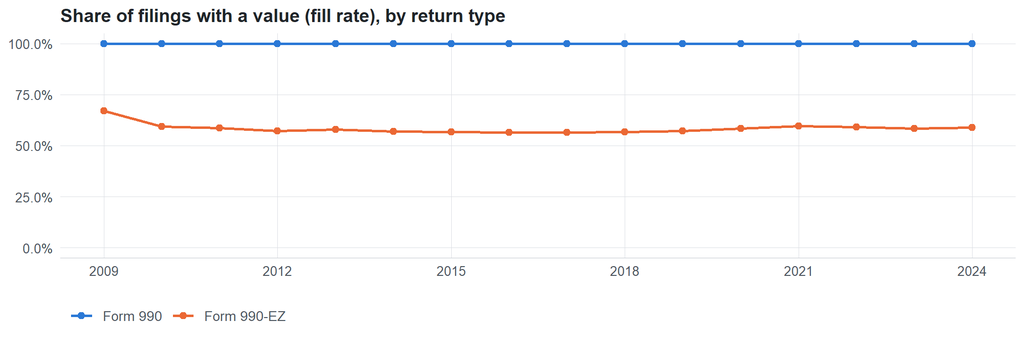

**Table view**

Table view: fill rate

| Tax year | Return type | Filings | All filings | Fill rate |
| --- | --- | --- | --- | --- |
| 2009 | Form 990 | 33,311 | 33,311 | 100.00% |
| 2009 | Form 990-EZ | 10,364 | 15,470 | 66.99% |
| 2010 | Form 990 | 123,025 | 123,025 | 100.00% |
| 2010 | Form 990-EZ | 37,609 | 63,326 | 59.39% |
| 2011 | Form 990 | 159,504 | 159,504 | 100.00% |
| 2011 | Form 990-EZ | 48,044 | 82,048 | 58.56% |
| 2012 | Form 990 | 179,688 | 179,688 | 100.00% |
| 2012 | Form 990-EZ | 53,534 | 93,750 | 57.10% |
| 2013 | Form 990 | 198,855 | 198,855 | 100.00% |
| 2013 | Form 990-EZ | 60,395 | 104,375 | 57.86% |
| 2014 | Form 990 | 218,619 | 218,619 | 100.00% |
| 2014 | Form 990-EZ | 66,344 | 116,417 | 56.99% |
| 2015 | Form 990 | 233,519 | 233,519 | 100.00% |
| 2015 | Form 990-EZ | 70,824 | 124,894 | 56.71% |
| 2016 | Form 990 | 243,903 | 243,903 | 100.00% |
| 2016 | Form 990-EZ | 73,730 | 130,484 | 56.51% |
| 2017 | Form 990 | 261,612 | 261,612 | 100.00% |
| 2017 | Form 990-EZ | 78,483 | 139,144 | 56.40% |
| 2018 | Form 990 | 271,442 | 271,442 | 100.00% |
| 2018 | Form 990-EZ | 84,562 | 149,384 | 56.61% |
| 2019 | Form 990 | 283,694 | 283,694 | 100.00% |
| 2019 | Form 990-EZ | 87,435 | 152,622 | 57.29% |
| 2020 | Form 990 | 320,342 | 320,342 | 100.00% |
| 2020 | Form 990-EZ | 99,041 | 169,864 | 58.31% |
| 2021 | Form 990 | 336,480 | 336,480 | 100.00% |
| 2021 | Form 990-EZ | 120,692 | 202,724 | 59.54% |
| 2022 | Form 990 | 349,055 | 349,055 | 100.00% |
| 2022 | Form 990-EZ | 121,640 | 206,130 | 59.01% |
| 2023 | Form 990 | 354,768 | 354,768 | 100.00% |
| 2023 | Form 990-EZ | 120,395 | 206,379 | 58.34% |
| 2024 | Form 990 | 277,298 | 277,298 | 100.00% |
| 2024 | Form 990-EZ | 105,167 | 178,867 | 58.80% |

## Values

| Result | Check | Detail |
| --- | --- | --- |
| ✓ pass | Values parse as numbers | 100.0% of values are numeric |
| ▲ warn | No sudden change in the median between adjacent years | largest change 6.5x (IRS990EZ/SumOfTotalLiabilities/BOY, 990EZ, TY2010) |
| ▲ warn | Pooled xpaths are on the same scale (same return type) | largest ratio of medians between xpaths: 8.5x |
| ⓘ info | Sign convention | 0.19% of values are negative (fine for net amounts, suspicious for gross amounts) |

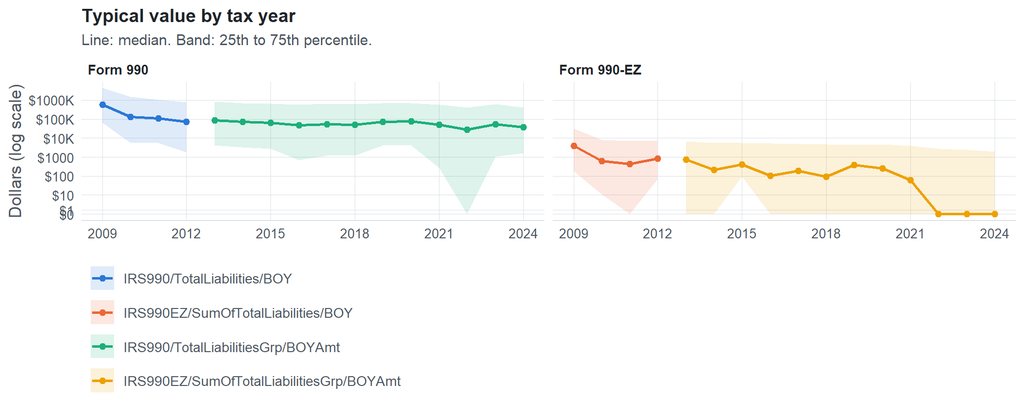

**Table view**

Table view: quartiles by tax year

| Series | Return | Tax year | Filings | P25 | Median | P75 |
| --- | --- | --- | --- | --- | --- | --- |
| IRS990/TotalLiabilities/BOY | 990 | 2009 | 33,311 | 62,957 | 585,104 | 4,249,069 |
| IRS990/TotalLiabilities/BOY | 990 | 2010 | 123,025 | 5,765 | 134,479 | 1,459,356 |
| IRS990/TotalLiabilities/BOY | 990 | 2011 | 159,504 | 5,783 | 106,791 | 1,057,573 |
| IRS990/TotalLiabilities/BOY | 990 | 2012 | 179,688 | 1,774 | 71,812 | 790,312 |
| IRS990EZ/SumOfTotalLiabilities/BOY | 990EZ | 2009 | 10,364 | 183.48 | 3,970 | 32,400 |
| IRS990EZ/SumOfTotalLiabilities/BOY | 990EZ | 2010 | 37,609 | 10.95 | 607.25 | 7,947 |
| IRS990EZ/SumOfTotalLiabilities/BOY | 990EZ | 2011 | 48,044 | 0 | 433.35 | 7,292 |
| IRS990EZ/SumOfTotalLiabilities/BOY | 990EZ | 2012 | 53,534 | 70.01 | 855.56 | 7,407 |
| IRS990/TotalLiabilitiesGrp/BOYAmt | 990 | 2013 | 198,855 | 4,171 | 85,450 | 831,333 |
| IRS990/TotalLiabilitiesGrp/BOYAmt | 990 | 2014 | 218,619 | 3,280 | 71,369 | 687,220 |
| IRS990/TotalLiabilitiesGrp/BOYAmt | 990 | 2015 | 233,519 | 2,822 | 65,799 | 665,454 |
| IRS990/TotalLiabilitiesGrp/BOYAmt | 990 | 2016 | 243,903 | 688.57 | 47,173 | 564,928 |
| IRS990/TotalLiabilitiesGrp/BOYAmt | 990 | 2017 | 261,612 | 1,195 | 53,382 | 632,074 |
| IRS990/TotalLiabilitiesGrp/BOYAmt | 990 | 2018 | 271,442 | 1,216 | 50,195 | 608,412 |
| IRS990/TotalLiabilitiesGrp/BOYAmt | 990 | 2019 | 283,694 | 4,062 | 71,673 | 670,191 |
| IRS990/TotalLiabilitiesGrp/BOYAmt | 990 | 2020 | 320,342 | 4,219 | 74,769 | 675,580 |
| IRS990/TotalLiabilitiesGrp/BOYAmt | 990 | 2021 | 336,480 | 280.12 | 49,260 | 577,032 |
| IRS990/TotalLiabilitiesGrp/BOYAmt | 990 | 2022 | 349,055 | 0 | 27,638 | 392,874 |
| IRS990/TotalLiabilitiesGrp/BOYAmt | 990 | 2023 | 354,768 | 1,082 | 53,870 | 602,849 |
| IRS990/TotalLiabilitiesGrp/BOYAmt | 990 | 2024 | 277,298 | 1,642 | 37,635 | 394,516 |
| IRS990EZ/SumOfTotalLiabilitiesGrp/BOYAmt | 990EZ | 2013 | 60,395 | 0 | 728.98 | 6,908 |
| IRS990EZ/SumOfTotalLiabilitiesGrp/BOYAmt | 990EZ | 2014 | 66,344 | 0 | 213.56 | 5,703 |
| IRS990EZ/SumOfTotalLiabilitiesGrp/BOYAmt | 990EZ | 2015 | 70,824 | 94.11 | 411.69 | 5,587 |
| IRS990EZ/SumOfTotalLiabilitiesGrp/BOYAmt | 990EZ | 2016 | 73,730 | 0 | 108.25 | 5,154 |
| IRS990EZ/SumOfTotalLiabilitiesGrp/BOYAmt | 990EZ | 2017 | 78,483 | 0 | 193.12 | 5,032 |
| IRS990EZ/SumOfTotalLiabilitiesGrp/BOYAmt | 990EZ | 2018 | 84,562 | 0 | 94.05 | 4,580 |
| IRS990EZ/SumOfTotalLiabilitiesGrp/BOYAmt | 990EZ | 2019 | 87,435 | 0 | 378.69 | 4,461 |
| IRS990EZ/SumOfTotalLiabilitiesGrp/BOYAmt | 990EZ | 2020 | 99,041 | 0 | 259.86 | 4,816 |
| IRS990EZ/SumOfTotalLiabilitiesGrp/BOYAmt | 990EZ | 2021 | 120,692 | 0 | 62.78 | 3,888 |
| IRS990EZ/SumOfTotalLiabilitiesGrp/BOYAmt | 990EZ | 2022 | 121,640 | 0 | 0 | 2,688 |
| IRS990EZ/SumOfTotalLiabilitiesGrp/BOYAmt | 990EZ | 2023 | 120,395 | 0 | 0 | 2,508 |
| IRS990EZ/SumOfTotalLiabilitiesGrp/BOYAmt | 990EZ | 2024 | 105,167 | 0 | 0 | 1,928 |

Summary by xpath and return type (all years)

| Series | Return | Filings | % numeric | % zero | % negative | Median (typical year) | P99 (typical year) |
| --- | --- | --- | --- | --- | --- | --- | --- |
| IRS990/TotalLiabilities/BOY | 990 | 495,528 | 100 | 19.6 | 0.1 | 92798 | 173071699 |
| IRS990EZ/SumOfTotalLiabilities/BOY | 990EZ | 149,551 | 100 | 43.1 | 0 | 1654 | 445732 |
| IRS990/TotalLiabilitiesGrp/BOYAmt |  | 26 |  |  |  |  |  |
| IRS990/TotalLiabilitiesGrp/BOYAmt | 990 | 3,349,587 | 100 | 25.9 | 0.3 | 28065 | 125424350 |
| IRS990EZ/SumOfTotalLiabilitiesGrp/BOYAmt |  | 1 |  |  |  |  |  |
| IRS990EZ/SumOfTotalLiabilitiesGrp/BOYAmt | 990EZ | 1,088,708 | 100 | 53.8 | 0 | 0 | 314943 |

## Examples

| Tax year | Return | Xpath | Organization | Value | Source |
| --- | --- | --- | --- | --- | --- |
| 2024 | 990 | IRS990/TotalLiabilitiesGrp/BOYAmt | OWL CREEK COUNTRY CLUB | 4453640 | [XML](https://gt990datalake-rawdata.s3.amazonaws.com/EfileData/XmlFiles/202513219349315726_public.xml) |
| 2024 | 990EZ | IRS990EZ/SumOfTotalLiabilitiesGrp/BOYAmt | Science & Technology Education Project | 0 | [XML](https://gt990datalake-rawdata.s3.amazonaws.com/EfileData/XmlFiles/202531709349200103_public.xml) |
| 2023 | 990 | IRS990/TotalLiabilitiesGrp/BOYAmt | COMMUNITY AMBULANCE SERVICE | 254909 | [XML](https://gt990datalake-rawdata.s3.amazonaws.com/EfileData/XmlFiles/202540169349300304_public.xml) |
| 2023 | 990EZ | IRS990EZ/SumOfTotalLiabilitiesGrp/BOYAmt | LAGRANGE WOMAN’S CLUB | 236 | [XML](https://gt990datalake-rawdata.s3.amazonaws.com/EfileData/XmlFiles/202422379349200502_public.xml) |
| 2022 | 990 | IRS990/TotalLiabilitiesGrp/BOYAmt | BRANDYWINE VFW POST 845 | 0 | [XML](https://gt990datalake-rawdata.s3.amazonaws.com/EfileData/XmlFiles/202311649349300031_public.xml) |
| 2022 | 990EZ | IRS990EZ/SumOfTotalLiabilitiesGrp/BOYAmt | BEHIND CLOSED DOORS MINISTRIES | 0 | [XML](https://gt990datalake-rawdata.s3.amazonaws.com/EfileData/XmlFiles/202311239349202216_public.xml) |
| 2021 | 990 | IRS990/TotalLiabilitiesGrp/BOYAmt | WEST TENNESSEE BUILDERS CARE FOUNDATION | 0 | [XML](https://gt990datalake-rawdata.s3.amazonaws.com/EfileData/XmlFiles/202331329349301558_public.xml) |
| 2021 | 990EZ | IRS990EZ/SumOfTotalLiabilitiesGrp/BOYAmt | KENILWORTH GARDEN CLUB | 0 | [XML](https://gt990datalake-rawdata.s3.amazonaws.com/EfileData/XmlFiles/202203439349200605_public.xml) |
| 2020 | 990 | IRS990/TotalLiabilitiesGrp/BOYAmt | CHARLOTTE HARBOR WATER ASSOCIATION INC | 807081 | [XML](https://gt990datalake-rawdata.s3.amazonaws.com/EfileData/XmlFiles/202132739349301608_public.xml) |
| 2020 | 990EZ | IRS990EZ/SumOfTotalLiabilitiesGrp/BOYAmt | GENESEE TOWNSHIP VETERANS MEMORIAL | 0 | [XML](https://gt990datalake-rawdata.s3.amazonaws.com/EfileData/XmlFiles/202142879349200014_public.xml) |
| 2019 | 990 | IRS990/TotalLiabilitiesGrp/BOYAmt | Chauffeurs Teamsters & Helpers Local 878 | 68846 | [XML](https://gt990datalake-rawdata.s3.amazonaws.com/EfileData/XmlFiles/202043219349315409_public.xml) |
| 2019 | 990EZ | IRS990EZ/SumOfTotalLiabilitiesGrp/BOYAmt | SINGING RIVER SERVICES GROUP HOME INC | 8733 | [XML](https://gt990datalake-rawdata.s3.amazonaws.com/EfileData/XmlFiles/202110419349200106_public.xml) |

## Reviewer checklist

- The definition matches the form line and instructions for every xpath’s schema years.
- Every xpath pooled here measures the same thing on the 990 and 990-EZ (close enough for analysis).
- The coverage chart has no unexplained gaps or jumps between tax years.
- Each open flag is fixed, or accepted with a note in validation_log.csv.
- Values are whole dollars, not thousands, and not a percentage.
- Current year / prior year and beginning / end of year match the variable name (CY, PY, BOY, EOY).
- Negative values are expected only for net amounts (gains, net income, fund balances).
- The 990 and 990-EZ medians differ only as much as the filer populations do.

Record the review as a row in `inst/extdata/src/validation_log.csv` (variable_name, reviewer, date, status, note). Evidence built 2026-09-23 17:09:04 MST from the ef2 DuckDB builds, TY2009–2024.